## Beer Map

by: *Jesse Zlotoff*

A friend and fellow beer lover has a map of the U.S. with slots for beer caps (like [this](https://www.amazon.com/Holder-Beautiful-Wooden-Shoe-Designs/dp/B00UU8M2R6/ref=asc_df_B00UU8M2R6/)). The slots are evenly spaced so it’s pretty difficult to line each one up with a state. There are also, presumably, differences in the number of beers available in each state. For example, there are probably fewer breweries in a less populous state like Montana than Michigan.

I look at the distribution of craft beers in the United States. The number of breweries per state is listed below.[^1] California has far and away the most. To account for the size of each state I also calculate the number of breweries per 100,000 people.[^2] In the graph below the table we see that California is pretty low on brewery density while some of the smaller states are quite high.

| State | Number of Breweries | Breweries per 100K People |
| --- | --- | --- |
| California | 788 | 1.99 |
| Washington | 382 | 5.16 |
| New York | 368 | 1.85 |
| Colorado | 358 | 6.38 |
| Michigan | 328 | 3.29 |
| Pennsylvania | 302 | 2.36 |
| Florida | 268 | 1.28 |
| North Carolina | 267 | 2.60 |
| Texas | 267 | 0.94 |
| Oregon | 256 | 6.18 |
| Ohio | 254 | 2.18 |
| Illinois | 221 | 1.73 |
| Virginia | 203 | 2.40 |
| Wisconsin | 188 | 3.24 |
| Minnesota | 162 | 2.90 |
| Massachusetts | 154 | 2.24 |
| Indiana | 151 | 2.26 |
| Arizona | 108 | 1.54 |
| Maine | 105 | 7.86 |
| New Jersey | 104 | 1.15 |
| Missouri | 101 | 1.65 |
| Maryland | 90 | 1.49 |
| Tennessee | 84 | 1.25 |
| Montana | 82 | 7.81 |
| Georgia | 80 | 0.77 |
| Iowa | 80 | 2.54 |
| Connecticut | 77 | 2.15 |
| New Mexico | 74 | 3.54 |
| New Hampshire | 73 | 5.44 |
| South Carolina | 69 | 1.37 |
| Idaho | 58 | 3.38 |
| Vermont | 56 | 8.98 |
| Kentucky | 54 | 1.21 |
| Nebraska | 42 | 2.19 |
| Nevada | 41 | 1.37 |
| Alaska | 40 | 5.41 |
| Alabama | 38 | 0.78 |
| Kansas | 38 | 1.30 |
| Arkansas | 37 | 1.23 |
| Louisiana | 37 | 0.79 |
| Oklahoma | 34 | 0.86 |
| Utah | 32 | 1.03 |
| Delaware | 26 | 2.70 |
| West Virginia | 26 | 1.43 |
| Wyoming | 26 | 4.49 |
| Rhode Island | 23 | 2.17 |
| South Dakota | 23 | 2.64 |
| Hawaii | 19 | 1.33 |
| Mississippi | 15 | 0.50 |
| District of Columbia | 14 | 2.02 |
| North Dakota | 14 | 1.85 |

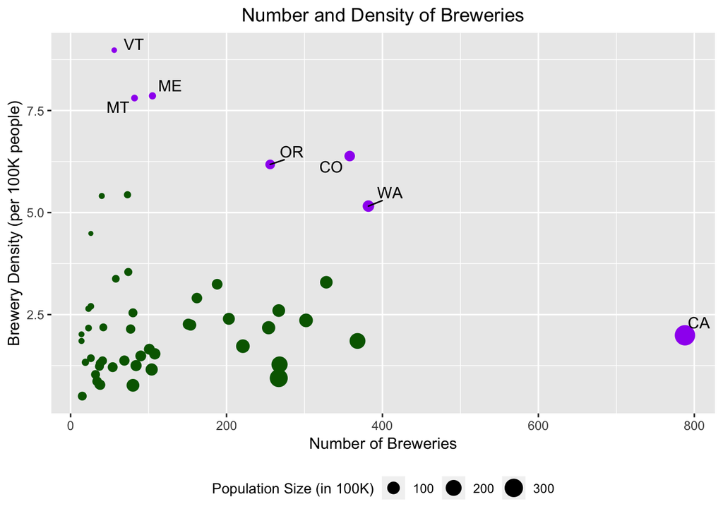

This is what it looks like in map form.

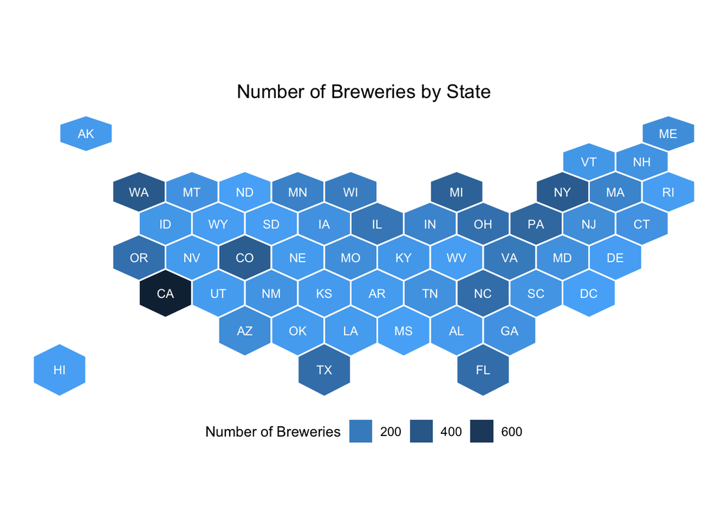

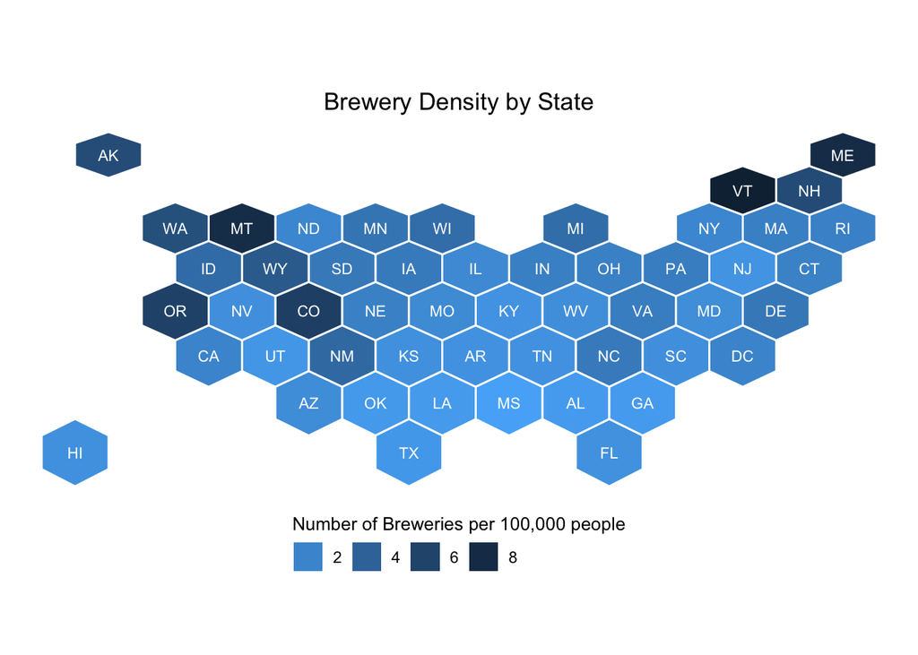

I resize the state hexagons by the number of breweries.

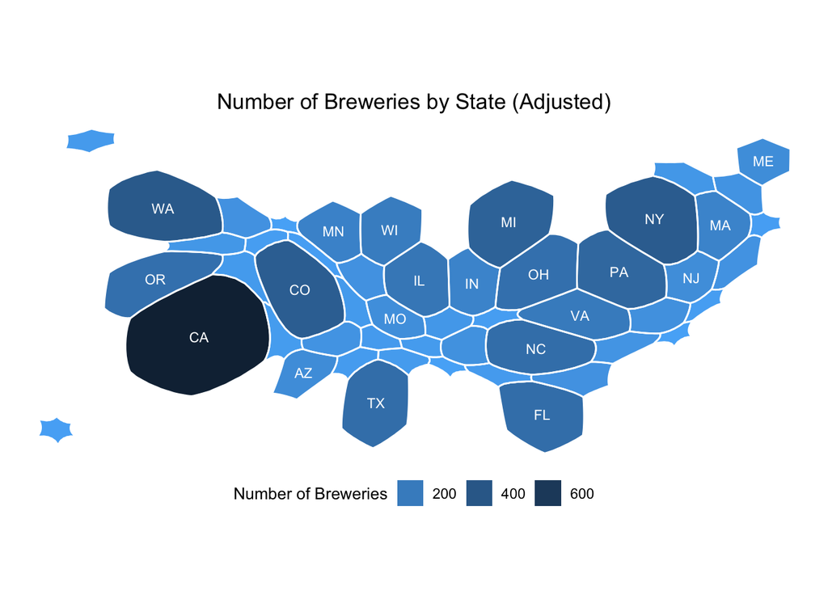

Quantity is not the same as quality, of course. There are few sources of beer rating data available for this type of analysis so I use my own beer ratings from the Untappd app. This is highly subjective and incomplete – it only has beers I’ve tried and rated. Trying to assess brewery quality from a biased sample of beer ratings and building state averages from this sample of breweries is problematic at best. I still use this data but draw no broader conclusions from it.

The table below shows the average and top brewery rating in the 33 states where I have data. Michigan, New York and Oregon each have a brewery with at least one beer rated 5 out of 5.

| State | Avg. Rating | Top Rating | Num. Breweries | Num. Beers | Min. Brewery Avg. | Max Brewery Avg. |
| --- | --- | --- | --- | --- | --- | --- |
| HI | 3.8 | 4.2 | 2 | 3 | 3.6 | 4.0 |
| IN | 3.8 | 4.0 | 1 | 2 | 3.8 | 3.8 |
| NH | 3.8 | 4.0 | 1 | 3 | 3.8 | 3.8 |
| OH | 3.5 | 4.0 | 1 | 6 | 3.5 | 3.5 |
| MN | 3.5 | 3.5 | 1 | 1 | 3.5 | 3.5 |
| RI | 3.5 | 3.5 | 1 | 1 | 3.5 | 3.5 |
| MI | 3.4 | 5.0 | 7 | 24 | 3.0 | 4.0 |
| MA | 3.4 | 4.8 | 4 | 12 | 3.0 | 3.8 |
| MO | 3.4 | 4.5 | 6 | 17 | 3.0 | 4.0 |
| DE | 3.4 | 4.0 | 2 | 10 | 3.3 | 3.6 |
| ME | 3.4 | 3.5 | 3 | 5 | 3.3 | 3.5 |
| OR | 3.3 | 5.0 | 6 | 18 | 3.0 | 3.8 |
| IL | 3.3 | 4.8 | 4 | 10 | 3.0 | 3.9 |
| CO | 3.3 | 4.5 | 13 | 35 | 2.0 | 4.5 |
| PA | 3.3 | 4.5 | 10 | 22 | 2.0 | 4.0 |
| CA | 3.3 | 4.5 | 20 | 76 | 2.9 | 3.8 |
| DC | 3.3 | 4.0 | 6 | 18 | 3.0 | 3.7 |
| WA | 3.3 | 4.0 | 3 | 6 | 3.0 | 3.5 |
| VT | 3.3 | 3.8 | 4 | 7 | 2.8 | 3.8 |
| NY | 3.2 | 5.0 | 7 | 16 | 3.0 | 3.4 |
| NC | 3.2 | 4.0 | 5 | 12 | 2.5 | 4.0 |
| VA | 3.2 | 4.0 | 11 | 22 | 2.8 | 3.5 |
| ID | 3.2 | 3.5 | 2 | 6 | 2.8 | 3.5 |
| GA | 3.2 | 3.5 | 1 | 2 | 3.2 | 3.2 |
| MD | 3.1 | 4.0 | 9 | 27 | 2.0 | 3.5 |
| TX | 3.1 | 3.5 | 5 | 9 | 2.7 | 3.2 |
| CT | 3.0 | 3.0 | 1 | 1 | 3.0 | 3.0 |
| LA | 3.0 | 3.0 | 2 | 3 | 3.0 | 3.0 |
| NJ | 3.0 | 3.0 | 1 | 2 | 3.0 | 3.0 |
| UT | 3.0 | 3.0 | 1 | 3 | 3.0 | 3.0 |
| WI | 2.9 | 3.5 | 2 | 3 | 2.2 | 3.5 |
| FL | 2.5 | 3.0 | 2 | 2 | 2.0 | 3.0 |
| SC | 2.1 | 3.2 | 2 | 2 | 1.0 | 3.2 |

I’ve only rated a few breweries in each state. I sum the brewery average in each state to get a total state score. Applying this to the map makes California really big. In addition, DC and the surrounding states are heavily weighted since those beers are the easiest to find.

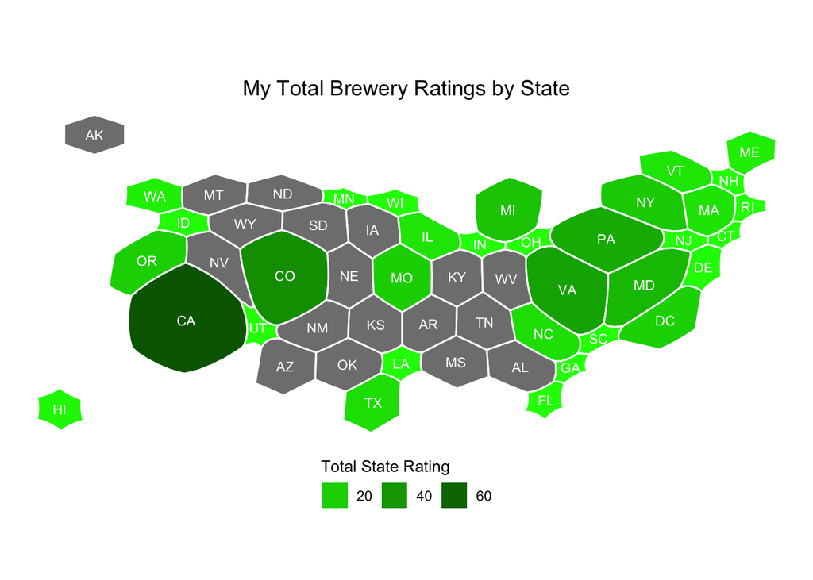

#### Acknowledgements

This analysis wouldn’t have been possible without the many others who have done something similar and graciously shared their code.  
[Hexbin map](https://www.r-graph-gallery.com/328-hexbin-map-of-the-usa/)  
[Area cartograms (resizing maps by data)](https://www.r-bloggers.com/cartograms-with-r/)

[^1]: Data from [Brewer’s Association](https://www.brewersassociation.org/directories/breweries/) as of 8/18/18
[^2]: Population figures from [2017 Census Estimates](https://factfinder.census.gov/faces/tableservices/jsf/pages/productview.xhtml?pid=PEP_2017_PEPANNRES&prodType=table)